# stats_python

<h1 id="Statistics-Walkthrough-with-Python">Statistics Walkthrough with Python</h1><p>This notebook performs exploratory data analysis, hypothesis testing, and regression modeling on three datasets from the repository `data/` folder. Analyses use **pandas**, **NumPy**, **SciPy**, **statsmodels**, **seaborn**, and **matplotlib**.</p> <p>**Reproducibility:** A fixed random seed (`RANDOM_SEED = 42`) is set wherever simulated or resampled quantities appear.</p>

```python
# Global imports and reproducibility settings
import warnings
from pathlib import Path

import matplotlib.pyplot as plt
import numpy as np
import pandas as pd
import seaborn as sns
import statsmodels.api as sm
import statsmodels.formula.api as smf
from scipy import stats
from statsmodels.stats.anova import anova_lm
from statsmodels.stats.diagnostic import het_breuschpagan
from statsmodels.stats.multicomp import pairwise_tukeyhsd

warnings.filterwarnings("ignore", category=FutureWarning)

RANDOM_SEED = 42
np.random.seed(RANDOM_SEED)

# Resolve data directory relative to this notebook (ai/ -> ../data/)
DATA_DIR = Path("..").resolve() / "data"

sns.set_theme(style="whitegrid", context="notebook")
plt.rcParams["figure.figsize"] = (8, 5)

print(f"Data directory: {DATA_DIR}")
```

```
Data directory: /users/PAS3421/frair7/Assignment4/data
```

<hr /> <h2 id="Part-1:-Brain-Size-and-Intelligence-(brain_size.csv)">Part 1: Brain Size and Intelligence (`brain_size.csv`)</h2><p>**Research questions**</p>

- What variables are recorded, and what do their distributions look like?
- Do males and females differ on IQ-related measures or brain volume (MRI count)?
- After controlling for gender, is full-scale IQ (FSIQ) associated with MRI_Count?

<p>**Selected tests and rationale**</p> <thead> <th>Analysis</th> <th>Test</th> <th>Why</th> </thead> <tbody> </tbody>

| Gender comparisons | Welch's two-sample *t*-test (primary) | Compares independent group means; Welch correction handles unequal variances with small *n* |
| --- | --- | --- |
| Non-parametric backup | Mann–Whitney *U* | Robust alternative if normality is questionable in small samples |
| IQ ~ brain volume | Multiple linear regression (OLS) | Estimates adjusted association while controlling for gender |
| Model assumptions | Residual plots, Q–Q plot, Breusch–Pagan | Visual and formal checks for linearity, normality, and homoscedasticity |

<h3 id="1.1-Load-and-Inspect-the-Data">1.1 Load and Inspect the Data</h3>

```python
# Read semicolon-delimited file; treat "." as missing
brain_raw = pd.read_csv(
    DATA_DIR / "brain_size.csv",
    sep=";",
    na_values=["."],
)

# Drop the unnamed index column if present
brain = brain_raw.drop(columns=[brain_raw.columns[0]], errors="ignore")
brain.columns = [c.strip('"') for c in brain.columns]

print("First rows:")
display(brain.head())

print("\nStructure and non-null counts:")
brain.info()

print("\nMissing values per column:")
print(brain.isna().sum())
```

```
First rows:
```

<style scoped> .dataframe tbody tr th:only-of-type { vertical-align: middle; } .dataframe tbody tr th { vertical-align: top; } .dataframe thead th { text-align: right; } </style> <thead> <th></th> <th>Gender</th> <th>FSIQ</th> <th>VIQ</th> <th>PIQ</th> <th>Weight</th> <th>Height</th> <th>MRI_Count</th> </thead> <tbody> <th>0</th> <th>1</th> <th>2</th> <th>3</th> <th>4</th> </tbody>

| Female | 133 | 132 | 124 | 118.0 | 64.5 | 816932 |
| --- | --- | --- | --- | --- | --- | --- |
| Male | 140 | 150 | 124 | NaN | 72.5 | 1001121 |
| Male | 139 | 123 | 150 | 143.0 | 73.3 | 1038437 |
| Male | 133 | 129 | 128 | 172.0 | 68.8 | 965353 |
| Female | 137 | 132 | 134 | 147.0 | 65.0 | 951545 |

```
Structure and non-null counts:
<class 'pandas.core.frame.DataFrame'>
RangeIndex: 40 entries, 0 to 39
Data columns (total 7 columns):
 #   Column     Non-Null Count  Dtype
---  ------     --------------  -----
 0   Gender     40 non-null     object
 1   FSIQ       40 non-null     int64
 2   VIQ        40 non-null     int64
 3   PIQ        40 non-null     int64
 4   Weight     38 non-null     float64
 5   Height     39 non-null     float64
 6   MRI_Count  40 non-null     int64
dtypes: float64(2), int64(4), object(1)
memory usage: 2.3+ KB

Missing values per column:
Gender       0
FSIQ         0
VIQ          0
PIQ          0
Weight       2
Height       1
MRI_Count    0
dtype: int64
```

```python
# Variable summary: IQ scores (FSIQ, VIQ, PIQ), anthropometrics, and MRI_Count
print("Unique gender labels:", brain["Gender"].unique())
print("\nGender counts:")
print(brain["Gender"].value_counts())

# Brief description of each variable for interpretation
variable_notes = {
    "FSIQ": "Full-scale IQ (overall intelligence score)",
    "VIQ": "Verbal IQ",
    "PIQ": "Performance IQ",
    "Weight": "Body weight (pounds)",
    "Height": "Height (inches)",
    "MRI_Count": "Voxel count from MRI (proxy for brain size/volume)",
}
for var, desc in variable_notes.items():
    print(f"  {var}: {desc}")
```

```
Unique gender labels: ['Female' 'Male']

Gender counts:
Gender
Female    20
Male      20
Name: count, dtype: int64
  FSIQ: Full-scale IQ (overall intelligence score)
  VIQ: Verbal IQ
  PIQ: Performance IQ
  Weight: Body weight (pounds)
  Height: Height (inches)
  MRI_Count: Voxel count from MRI (proxy for brain size/volume)
```

<h3 id="1.2-Descriptive-Statistics">1.2 Descriptive Statistics</h3>

```python
# Numeric summaries for the full sample
numeric_cols = ["FSIQ", "VIQ", "PIQ", "Weight", "Height", "MRI_Count"]
desc_all = brain[numeric_cols].describe().T
desc_all["IQR"] = desc_all["75%"] - desc_all["25%"]

print("Overall descriptive statistics:")
display(desc_all.round(2))

# Grouped summaries by gender help contextualize later hypothesis tests
desc_by_gender = brain.groupby("Gender")[numeric_cols].agg(["mean", "std", "median", "count"])
print("\nDescriptive statistics by gender:")
display(desc_by_gender.round(2))
```

```
Overall descriptive statistics:
```

<style scoped> .dataframe tbody tr th:only-of-type { vertical-align: middle; } .dataframe tbody tr th { vertical-align: top; } .dataframe thead th { text-align: right; } </style> <thead> <th></th> <th>count</th> <th>mean</th> <th>std</th> <th>min</th> <th>25%</th> <th>50%</th> <th>75%</th> <th>max</th> <th>IQR</th> </thead> <tbody> <th>FSIQ</th> <th>VIQ</th> <th>PIQ</th> <th>Weight</th> <th>Height</th> <th>MRI_Count</th> </tbody>

| 40.0 | 113.45 | 24.08 | 77.0 | 89.75 | 116.5 | 135.50 | 144.0 | 45.75 |
| --- | --- | --- | --- | --- | --- | --- | --- | --- |
| 40.0 | 112.35 | 23.62 | 71.0 | 90.00 | 113.0 | 129.75 | 150.0 | 39.75 |
| 40.0 | 111.02 | 22.47 | 72.0 | 88.25 | 115.0 | 128.00 | 150.0 | 39.75 |
| 38.0 | 151.05 | 23.48 | 106.0 | 135.25 | 146.5 | 172.00 | 192.0 | 36.75 |
| 39.0 | 68.53 | 3.99 | 62.0 | 66.00 | 68.0 | 70.50 | 77.0 | 4.50 |
| 40.0 | 908755.00 | 72282.05 | 790619.0 | 855918.50 | 905399.0 | 950078.00 | 1079549.0 | 94159.50 |

```
Descriptive statistics by gender:
```

<style scoped> .dataframe tbody tr th:only-of-type { vertical-align: middle; } .dataframe tbody tr th { vertical-align: top; } .dataframe thead tr th { text-align: left; } .dataframe thead tr:last-of-type th { text-align: right; } </style> <thead> <th></th> <th colspan="4" halign="left">FSIQ</th> <th colspan="4" halign="left">VIQ</th> <th colspan="2" halign="left">PIQ</th> <th>...</th> <th colspan="2" halign="left">Weight</th> <th colspan="4" halign="left">Height</th> <th colspan="4" halign="left">MRI_Count</th> <th></th> <th>mean</th> <th>std</th> <th>median</th> <th>count</th> <th>mean</th> <th>std</th> <th>median</th> <th>count</th> <th>mean</th> <th>std</th> <th>...</th> <th>median</th> <th>count</th> <th>mean</th> <th>std</th> <th>median</th> <th>count</th> <th>mean</th> <th>std</th> <th>median</th> <th>count</th> <th>Gender</th> <th></th> <th></th> <th></th> <th></th> <th></th> <th></th> <th></th> <th></th> <th></th> <th></th> <th></th> <th></th> <th></th> <th></th> <th></th> <th></th> <th></th> <th></th> <th></th> <th></th> <th></th> </thead> <tbody> <th>Female</th> <th>Male</th> </tbody>

| 111.9 | 23.69 | 115.5 | 20 | 109.45 | 21.67 | 116.0 | 20 | 110.45 | 21.95 | ... | 138.5 | 20 | 65.76 | 2.29 | 66.0 | 20 | 862654.6 | 55893.56 | 855365.0 | 20 |
| --- | --- | --- | --- | --- | --- | --- | --- | --- | --- | --- | --- | --- | --- | --- | --- | --- | --- | --- | --- | --- |
| 115.0 | 24.99 | 118.0 | 20 | 115.25 | 25.64 | 110.5 | 20 | 111.60 | 23.54 | ... | 172.0 | 18 | 71.43 | 3.28 | 70.5 | 19 | 954855.4 | 55911.35 | 947241.5 | 20 |

<p>2 rows × 24 columns</p>

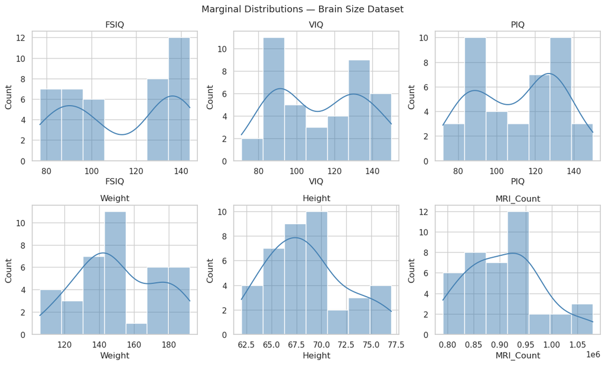

```python
# Distribution plots: histograms for IQ measures and MRI_Count
fig, axes = plt.subplots(2, 3, figsize=(12, 7))
for ax, col in zip(axes.ravel(), numeric_cols):
    sns.histplot(brain[col].dropna(), kde=True, ax=ax, color="steelblue")
    ax.set_title(col)
plt.tight_layout()
plt.suptitle("Marginal Distributions — Brain Size Dataset", y=1.02, fontsize=13)
plt.show()
```

<h3 id="1.3-Compare-Intelligence-Measures-Between-Groups-(Gender)">1.3 Compare Intelligence Measures Between Groups (Gender)</h3>

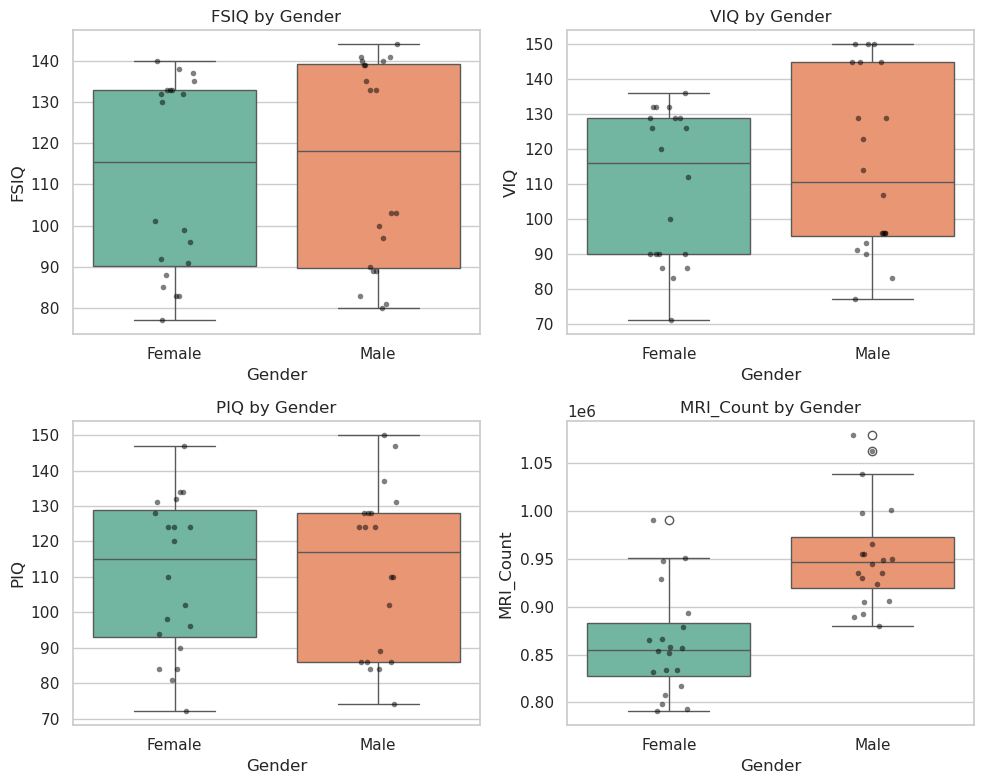

```python
# Boxplots visualize central tendency and spread by gender
iq_cols = ["FSIQ", "VIQ", "PIQ", "MRI_Count"]
fig, axes = plt.subplots(2, 2, figsize=(10, 8))
for ax, col in zip(axes.ravel(), iq_cols):
    sns.boxplot(data=brain, x="Gender", y=col, ax=ax, palette="Set2")
    sns.stripplot(data=brain, x="Gender", y=col, ax=ax, color="black", alpha=0.5, size=4)
    ax.set_title(f"{col} by Gender")
plt.tight_layout()
plt.show()
```

```python
def compare_two_groups(data, value_col, group_col, g1, g2):
    """
    Compare two independent groups using Welch's t-test and Mann-Whitney U.

    Welch's t-test does not assume equal variances — appropriate for small samples.
    Mann-Whitney U tests whether one group tends to have larger values (non-parametric).
    """
    x = data.loc[data[group_col] == g1, value_col].dropna()
    y = data.loc[data[group_col] == g2, value_col].dropna()

    t_stat, t_p = stats.ttest_ind(x, y, equal_var=False)  # Welch's t-test
    u_stat, u_p = stats.mannwhitneyu(x, y, alternative="two-sided")

    # Levene's test informs whether variance differs markedly between groups
    lev_stat, lev_p = stats.levene(x, y)

    return {
        "variable": value_col,
        f"{g1}_mean": x.mean(),
        f"{g2}_mean": y.mean(),
        "mean_diff": x.mean() - y.mean(),
        "welch_t_p": t_p,
        "mannwhitney_p": u_p,
        "levene_p": lev_p,
        "n1": len(x),
        "n2": len(y),
    }


gender_tests = [
    compare_two_groups(brain, col, "Gender", "Male", "Female")
    for col in iq_cols
]
gender_results = pd.DataFrame(gender_tests)

print("Gender comparison results (Male minus Female):")
display(gender_results.round(4))

print(
    "\nInterpretation: A small Welch p-value suggests a statistically significant "
    "difference in group means. Compare with Mann-Whitney p-values; agreement supports "
    "the finding regardless of normality assumptions."
)
```

```
Gender comparison results (Male minus Female):
```

<style scoped> .dataframe tbody tr th:only-of-type { vertical-align: middle; } .dataframe tbody tr th { vertical-align: top; } .dataframe thead th { text-align: right; } </style> <thead> <th></th> <th>variable</th> <th>Male_mean</th> <th>Female_mean</th> <th>mean_diff</th> <th>welch_t_p</th> <th>mannwhitney_p</th> <th>levene_p</th> <th>n1</th> <th>n2</th> </thead> <tbody> <th>0</th> <th>1</th> <th>2</th> <th>3</th> </tbody>

| FSIQ | 115.00 | 111.90 | 3.10 | 0.6895 | 0.3032 | 0.6238 | 20 | 20 |
| --- | --- | --- | --- | --- | --- | --- | --- | --- |
| VIQ | 115.25 | 109.45 | 5.80 | 0.4447 | 0.3423 | 0.3811 | 20 | 20 |
| PIQ | 111.60 | 110.45 | 1.15 | 0.8739 | 0.8921 | 0.7476 | 20 | 20 |
| MRI_Count | 954855.40 | 862654.60 | 92200.80 | 0.0000 | 0.0000 | 0.9563 | 20 | 20 |

```
Interpretation: A small Welch p-value suggests a statistically significant difference in group means. Compare with Mann-Whitney p-values; agreement supports the finding regardless of normality assumptions.
```

<h3 id="1.4-Linear-Regression:-FSIQ-~-MRI_Count-+-Gender">1.4 Linear Regression: FSIQ ~ MRI_Count + Gender</h3>

```python
# Complete-case subset for regression (listwise deletion of rows with any missing predictor/outcome)
brain_reg = brain.dropna(subset=["FSIQ", "MRI_Count", "Gender"]).copy()
brain_reg["Gender"] = pd.Categorical(brain_reg["Gender"])

print(f"Regression sample size: {len(brain_reg)} observations")

# OLS with formula interface: Gender is included as a categorical predictor
brain_model = smf.ols("FSIQ ~ MRI_Count + C(Gender)", data=brain_reg).fit()
print(brain_model.summary())
```

```
Regression sample size: 40 observations
                            OLS Regression Results
==============================================================================
Dep. Variable:                   FSIQ   R-squared:                       0.175
Model:                            OLS   Adj. R-squared:                  0.130
Method:                 Least Squares   F-statistic:                     3.927
Date:                Mon, 27 Jul 2026   Prob (F-statistic):             0.0284
Time:                        22:31:20   Log-Likelihood:                -179.66
No. Observations:                  40   AIC:                             365.3
Df Residuals:                      37   BIC:                             370.4
Df Model:                           2
Covariance Type:            nonrobust
=====================================================================================
                        coef    std err          t      P>|t|      [0.025      0.975]
-------------------------------------------------------------------------------------
Intercept           -43.7083     56.438     -0.774      0.444    -158.062      70.645
C(Gender)[T.Male]   -13.5315      9.302     -1.455      0.154     -32.379       5.316
MRI_Count             0.0002   6.52e-05      2.768      0.009    4.83e-05       0.000
==============================================================================
Omnibus:                       32.036   Durbin-Watson:                   1.548
Prob(Omnibus):                  0.000   Jarque-Bera (JB):                3.995
Skew:                           0.096   Prob(JB):                        0.136
Kurtosis:                       1.464   Cond. No.                     1.46e+07
==============================================================================

Notes:
[1] Standard Errors assume that the covariance matrix of the errors is correctly specified.
[2] The condition number is large, 1.46e+07. This might indicate that there are
strong multicollinearity or other numerical problems.
```

```python
# Coefficient interpretation in plain language
print("Coefficient interpretation:")
print(f"  Intercept: predicted FSIQ when MRI_Count = 0 and reference gender is {brain_reg['Gender'].cat.categories[0]}")
print("  MRI_Count: change in predicted FSIQ per additional voxel count unit (holding gender constant)")
print("  Gender terms: average FSIQ difference relative to the reference gender, adjusting for MRI_Count")
print(f"\nModel R-squared: {brain_model.rsquared:.3f} — fraction of FSIQ variance explained by predictors")
print(f"Overall F-test p-value: {brain_model.f_pvalue:.4g}")
```

```
Coefficient interpretation:
  Intercept: predicted FSIQ when MRI_Count = 0 and reference gender is Female
  MRI_Count: change in predicted FSIQ per additional voxel count unit (holding gender constant)
  Gender terms: average FSIQ difference relative to the reference gender, adjusting for MRI_Count

Model R-squared: 0.175 — fraction of FSIQ variance explained by predictors
Overall F-test p-value: 0.02842
```

<h3 id="1.5-Regression-Assumption-Checks">1.5 Regression Assumption Checks</h3>

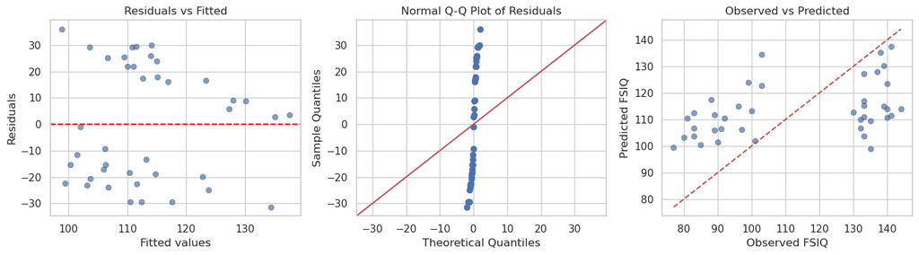

```
Breusch-Pagan test for heteroscedasticity: stat = 2.609, p = 0.2713
If p is large, we do not reject constant variance; if small, consider robust SEs or transformations.
```

```python
fitted = brain_model.fittedvalues
residuals = brain_model.resid

fig, axes = plt.subplots(1, 3, figsize=(14, 4))

# Residuals vs fitted: should show no curved pattern (linearity + homoscedasticity)
axes[0].scatter(fitted, residuals, alpha=0.7, edgecolor="k", linewidth=0.3)
axes[0].axhline(0, color="red", linestyle="--")
axes[0].set_xlabel("Fitted values")
axes[0].set_ylabel("Residuals")
axes[0].set_title("Residuals vs Fitted")

# Q-Q plot: points near the line support approximate normality of residuals
sm.qqplot(residuals, line="45", ax=axes[1])
axes[1].set_title("Normal Q-Q Plot of Residuals")

# Observed vs fitted: closeness to diagonal indicates good fit
axes[2].scatter(brain_reg["FSIQ"], fitted, alpha=0.7, edgecolor="k", linewidth=0.3)
lims = [min(brain_reg["FSIQ"].min(), fitted.min()), max(brain_reg["FSIQ"].max(), fitted.max())]
axes[2].plot(lims, lims, "r--")
axes[2].set_xlabel("Observed FSIQ")
axes[2].set_ylabel("Predicted FSIQ")
axes[2].set_title("Observed vs Predicted")

plt.tight_layout()
plt.show()

# Breusch-Pagan test: null hypothesis = homoscedastic residuals
bp_stat, bp_p, _, _ = het_breuschpagan(residuals, brain_model.model.exog)
print(f"Breusch-Pagan test for heteroscedasticity: stat = {bp_stat:.3f}, p = {bp_p:.4f}")
print("If p is large, we do not reject constant variance; if small, consider robust SEs or transformations.")
```

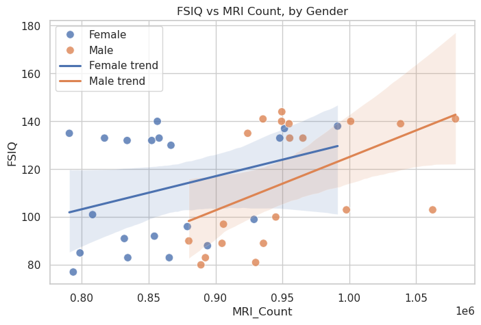

```python
# Scatter plot with separate regression lines by gender
plt.figure(figsize=(8, 5))
sns.scatterplot(data=brain_reg, x="MRI_Count", y="FSIQ", hue="Gender", s=70, alpha=0.8)
sns.regplot(
    data=brain_reg[brain_reg["Gender"] == "Female"],
    x="MRI_Count", y="FSIQ", scatter=False, color="C0", label="Female trend",
)
sns.regplot(
    data=brain_reg[brain_reg["Gender"] == "Male"],
    x="MRI_Count", y="FSIQ", scatter=False, color="C1", label="Male trend",
)
plt.title("FSIQ vs MRI Count, by Gender")
plt.legend()
plt.show()
```

<p>**Part 1 takeaway:** Descriptive tables and plots characterize IQ scores and brain-volume proxies. Welch *t*-tests (with Mann–Whitney backup) assess gender differences on each measure. The regression quantifies whether MRI_Count remains associated with FSIQ after adjusting for gender; diagnostic plots evaluate whether linear-model assumptions are reasonable for this small sample.</p>

<hr /> <h2 id="Part-2:-1985-CPS-Wages-(CPS_85_Wages.txt)">Part 2: 1985 CPS Wages (`CPS_85_Wages.txt`)</h2><p>**Research questions**</p>

- How are hourly wages distributed, and how do wages vary across demographic/employment groups?
- Which worker characteristics predict log wages after adjustment?

<p>**Selected tests and rationale**</p> <thead> <th>Analysis</th> <th>Test</th> <th>Why</th> </thead> <tbody> </tbody>

| Female vs male wages | Welch's *t*-test on raw wages; coefficient in log model | Simple group comparison plus adjusted gap in regression |
| --- | --- | --- |
| Union vs non-union | Welch's *t*-test | Two independent groups |
| Occupation categories | One-way ANOVA + Kruskal–Wallis | Multi-group comparison; non-parametric backup for skewed wages |
| Wage determinants | OLS on log(WAGE) | Stabilizes variance; coefficients ≈ proportional changes |
| Multicollinearity | Correlation of AGE vs EXPERIENCE | Documented r≈0.98 — include EXPERIENCE, exclude AGE |

<h3 id="2.1-Load,-Clean,-and-Inspect">2.1 Load, Clean, and Inspect</h3>

```python
# Column names from the data dictionary in the file header
cps_columns = [
    "EDUCATION", "SOUTH", "SEX", "EXPERIENCE", "UNION", "WAGE",
    "AGE", "RACE", "OCCUPATION", "SECTOR", "MARR",
]

# Skip descriptive header lines; whitespace-separated numeric rows begin around line 28
cps = pd.read_csv(
    DATA_DIR / "CPS_85_Wages.txt",
    sep=r"\s+",
    skiprows=27,
    names=cps_columns,
    engine="python",
)

# Ensure numeric types and drop accidental blank rows
cps = cps.apply(pd.to_numeric, errors="coerce").dropna(how="any").astype(int)

print(f"Sample size after cleaning: {len(cps)}")
display(cps.head())
print("\nData types and ranges:")
cps.info()
```

```
Sample size after cleaning: 534
```

<style scoped> .dataframe tbody tr th:only-of-type { vertical-align: middle; } .dataframe tbody tr th { vertical-align: top; } .dataframe thead th { text-align: right; } </style> <thead> <th></th> <th>EDUCATION</th> <th>SOUTH</th> <th>SEX</th> <th>EXPERIENCE</th> <th>UNION</th> <th>WAGE</th> <th>AGE</th> <th>RACE</th> <th>OCCUPATION</th> <th>SECTOR</th> <th>MARR</th> </thead> <tbody> <th>0</th> <th>1</th> <th>2</th> <th>3</th> <th>4</th> </tbody>

| 8 | 0 | 1 | 21 | 0 | 5 | 35 | 2 | 6 | 1 | 1 |
| --- | --- | --- | --- | --- | --- | --- | --- | --- | --- | --- |
| 9 | 0 | 1 | 42 | 0 | 4 | 57 | 3 | 6 | 1 | 1 |
| 12 | 0 | 0 | 1 | 0 | 6 | 19 | 3 | 6 | 1 | 0 |
| 12 | 0 | 0 | 4 | 0 | 4 | 22 | 3 | 6 | 0 | 0 |
| 12 | 0 | 0 | 17 | 0 | 7 | 35 | 3 | 6 | 0 | 1 |

```
Data types and ranges:
<class 'pandas.core.frame.DataFrame'>
Index: 534 entries, 0 to 533
Data columns (total 11 columns):
 #   Column      Non-Null Count  Dtype
---  ------      --------------  -----
 0   EDUCATION   534 non-null    int64
 1   SOUTH       534 non-null    int64
 2   SEX         534 non-null    int64
 3   EXPERIENCE  534 non-null    int64
 4   UNION       534 non-null    int64
 5   WAGE        534 non-null    int64
 6   AGE         534 non-null    int64
 7   RACE        534 non-null    int64
 8   OCCUPATION  534 non-null    int64
 9   SECTOR      534 non-null    int64
 10  MARR        534 non-null    int64
dtypes: int64(11)
memory usage: 50.1 KB
```

```python
# Human-readable labels for categorical variables aid interpretation
cps["sex_label"] = cps["SEX"].map({0: "Male", 1: "Female"})
cps["union_label"] = cps["UNION"].map({0: "Non-union", 1: "Union"})
cps["region_label"] = cps["SOUTH"].map({0: "Non-South", 1: "South"})
cps["occupation_label"] = cps["OCCUPATION"].map({
    1: "Management", 2: "Sales", 3: "Clerical", 4: "Service",
    5: "Professional", 6: "Other",
})

print("Unique counts for key categorical variables:")
for col in ["sex_label", "union_label", "region_label", "occupation_label"]:
    print(f"\n{col}:")
    print(cps[col].value_counts())
```

```
Unique counts for key categorical variables:

sex_label:
sex_label
Male      289
Female    245
Name: count, dtype: int64

union_label:
union_label
Non-union    438
Union         96
Name: count, dtype: int64

region_label:
region_label
Non-South    378
South        156
Name: count, dtype: int64

occupation_label:
occupation_label
Other           156
Professional    105
Clerical         97
Service          83
Management       55
Sales            38
Name: count, dtype: int64
```

<h3 id="2.2-Wage-Distributions-and-Demographic-Summaries">2.2 Wage Distributions and Demographic Summaries</h3>

```python
print("Hourly wage summary (dollars):")
display(cps["WAGE"].describe().to_frame().T.round(3))

print("\nDemographic / employment summaries:")
demo_summary = cps[["EDUCATION", "EXPERIENCE", "AGE"]].describe().T.round(2)
display(demo_summary)

# AGE and EXPERIENCE are nearly collinear — retain EXPERIENCE in regression
age_exp_r = cps[["AGE", "EXPERIENCE"]].corr().iloc[0, 1]
print(f"\nCorrelation(AGE, EXPERIENCE) = {age_exp_r:.3f} (multicollinearity concern if both included)")
```

```
Hourly wage summary (dollars):
```

<style scoped> .dataframe tbody tr th:only-of-type { vertical-align: middle; } .dataframe tbody tr th { vertical-align: top; } .dataframe thead th { text-align: right; } </style> <thead> <th></th> <th>count</th> <th>mean</th> <th>std</th> <th>min</th> <th>25%</th> <th>50%</th> <th>75%</th> <th>max</th> </thead> <tbody> <th>WAGE</th> </tbody>

| 534.0 | 8.635 | 5.151 | 1.0 | 5.0 | 7.0 | 11.0 | 44.0 |
| --- | --- | --- | --- | --- | --- | --- | --- |

```
Demographic / employment summaries:
```

<style scoped> .dataframe tbody tr th:only-of-type { vertical-align: middle; } .dataframe tbody tr th { vertical-align: top; } .dataframe thead th { text-align: right; } </style> <thead> <th></th> <th>count</th> <th>mean</th> <th>std</th> <th>min</th> <th>25%</th> <th>50%</th> <th>75%</th> <th>max</th> </thead> <tbody> <th>EDUCATION</th> <th>EXPERIENCE</th> <th>AGE</th> </tbody>

| 534.0 | 13.02 | 2.62 | 2.0 | 12.0 | 12.0 | 15.0 | 18.0 |
| --- | --- | --- | --- | --- | --- | --- | --- |
| 534.0 | 17.82 | 12.38 | 0.0 | 8.0 | 15.0 | 26.0 | 55.0 |
| 534.0 | 36.83 | 11.73 | 18.0 | 28.0 | 35.0 | 44.0 | 64.0 |

```
Correlation(AGE, EXPERIENCE) = 0.978 (multicollinearity concern if both included)
```

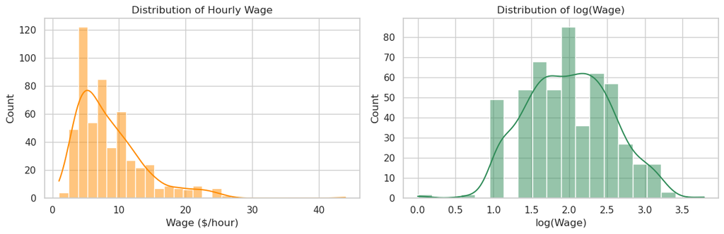

```python
fig, axes = plt.subplots(1, 2, figsize=(12, 4))

# Raw wages are right-skewed; log transform is common for regression
sns.histplot(cps["WAGE"], kde=True, ax=axes[0], color="darkorange")
axes[0].set_title("Distribution of Hourly Wage")
axes[0].set_xlabel("Wage ($/hour)")

cps["log_wage"] = np.log(cps["WAGE"])
sns.histplot(cps["log_wage"], kde=True, ax=axes[1], color="seagreen")
axes[1].set_title("Distribution of log(Wage)")
axes[1].set_xlabel("log(Wage)")

plt.tight_layout()
plt.show()
```

<h3 id="2.3-Compare-Wages-Between-Groups">2.3 Compare Wages Between Groups</h3>

```python
def welch_summary(data, value, group, labels=(0, 1), label_names=("Group0", "Group1")):
    g0 = data.loc[data[group] == labels[0], value]
    g1 = data.loc[data[group] == labels[1], value]
    t, p = stats.ttest_ind(g0, g1, equal_var=False)
    return {
        "comparison": f"{label_names[1]} vs {label_names[0]}",
        f"mean_{label_names[0]}": g0.mean(),
        f"mean_{label_names[1]}": g1.mean(),
        "welch_p": p,
    }

group_comparisons = [
    welch_summary(cps, "WAGE", "SEX", (0, 1), ("Male", "Female")),
    welch_summary(cps, "WAGE", "UNION", (0, 1), ("Non-union", "Union")),
    welch_summary(cps, "WAGE", "SOUTH", (0, 1), ("Non-South", "South")),
]
display(pd.DataFrame(group_comparisons).round(4))

# Multi-group occupation comparison
occ_groups = [cps.loc[cps["OCCUPATION"] == k, "WAGE"].values for k in sorted(cps["OCCUPATION"].unique())]
f_stat, f_p = stats.f_oneway(*occ_groups)
h_stat, h_p = stats.kruskal(*occ_groups)
print(f"Occupation ANOVA: F p-value = {f_p:.4g}")
print(f"Occupation Kruskal-Wallis: p-value = {h_p:.4g}")
```

<style scoped> .dataframe tbody tr th:only-of-type { vertical-align: middle; } .dataframe tbody tr th { vertical-align: top; } .dataframe thead th { text-align: right; } </style> <thead> <th></th> <th>comparison</th> <th>mean_Male</th> <th>mean_Female</th> <th>welch_p</th> <th>mean_Non-union</th> <th>mean_Union</th> <th>mean_Non-South</th> <th>mean_South</th> </thead> <tbody> <th>0</th> <th>1</th> <th>2</th> </tbody>

| Female vs Male | 9.6159 | 7.4776 | 0.0000 | NaN | NaN | NaN | NaN |
| --- | --- | --- | --- | --- | --- | --- | --- |
| Union vs Non-union | NaN | NaN | 0.0000 | 8.2283 | 10.4896 | NaN | NaN |
| South vs Non-South | NaN | NaN | 0.0007 | NaN | NaN | 9.1005 | 7.5064 |

```
Occupation ANOVA: F p-value = 3.506e-21
Occupation Kruskal-Wallis: p-value = 1.517e-18
```

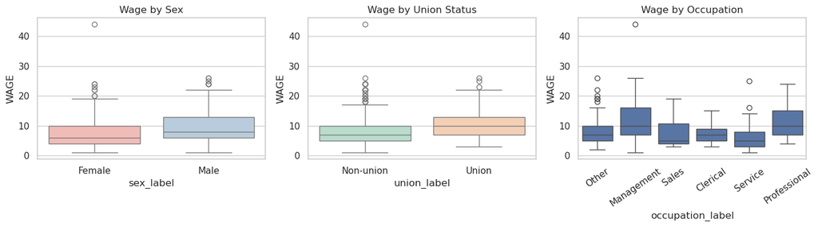

```python
fig, axes = plt.subplots(1, 3, figsize=(14, 4))
sns.boxplot(data=cps, x="sex_label", y="WAGE", ax=axes[0], palette="Pastel1")
axes[0].set_title("Wage by Sex")
sns.boxplot(data=cps, x="union_label", y="WAGE", ax=axes[1], palette="Pastel2")
axes[1].set_title("Wage by Union Status")
sns.boxplot(data=cps, x="occupation_label", y="WAGE", ax=axes[2])
axes[2].set_title("Wage by Occupation")
axes[2].tick_params(axis="x", rotation=35)
plt.tight_layout()
plt.show()
```

<h3 id="2.4-Regression-Model-for-Log-Wages">2.4 Regression Model for Log Wages</h3>

```python
# Multiple regression with categorical occupation; EXPERIENCE instead of AGE
wage_formula = "log_wage ~ EDUCATION + EXPERIENCE + SEX + UNION + SOUTH + C(OCCUPATION)"
wage_model = smf.ols(wage_formula, data=cps).fit()
print(wage_model.summary())
```

```
                            OLS Regression Results
==============================================================================
Dep. Variable:               log_wage   R-squared:                       0.354
Model:                            OLS   Adj. R-squared:                  0.342
Method:                 Least Squares   F-statistic:                     28.65
Date:                Mon, 27 Jul 2026   Prob (F-statistic):           8.01e-44
Time:                        22:34:05   Log-Likelihood:                -334.61
No. Observations:                 534   AIC:                             691.2
Df Residuals:                     523   BIC:                             738.3
Df Model:                          10
Covariance Type:            nonrobust
======================================================================================
                         coef    std err          t      P>|t|      [0.025      0.975]
--------------------------------------------------------------------------------------
Intercept              1.1372      0.183      6.225      0.000       0.778       1.496
C(OCCUPATION)[T.2]    -0.3737      0.098     -3.828      0.000      -0.565      -0.182
C(OCCUPATION)[T.3]    -0.2136      0.081     -2.632      0.009      -0.373      -0.054
C(OCCUPATION)[T.4]    -0.4412      0.086     -5.130      0.000      -0.610      -0.272
C(OCCUPATION)[T.5]    -0.0426      0.078     -0.548      0.584      -0.195       0.110
C(OCCUPATION)[T.6]    -0.2156      0.081     -2.669      0.008      -0.374      -0.057
EDUCATION              0.0738      0.011      6.980      0.000       0.053       0.095
EXPERIENCE             0.0113      0.002      6.375      0.000       0.008       0.015
SEX                   -0.2258      0.044     -5.092      0.000      -0.313      -0.139
UNION                  0.2310      0.054      4.255      0.000       0.124       0.338
SOUTH                 -0.1165      0.044     -2.629      0.009      -0.204      -0.029
==============================================================================
Omnibus:                       19.166   Durbin-Watson:                   1.921
Prob(Omnibus):                  0.000   Jarque-Bera (JB):               36.420
Skew:                          -0.202   Prob(JB):                     1.23e-08
Kurtosis:                       4.214   Cond. No.                         259.
==============================================================================

Notes:
[1] Standard Errors assume that the covariance matrix of the errors is correctly specified.
```

```python
# Extract coefficients with 95% confidence intervals
coef_table = wage_model.summary2().tables[1]
coef_table["pct_change_approx"] = (np.exp(coef_table["Coef."]) - 1) * 100

print("Coefficient table with approximate % change in wage per unit increase:")
display(coef_table.round(4))

print("\nHow to read log-wage coefficients:")
print("  - For continuous predictors, exp(beta) - 1 ≈ proportional change in wage per 1-unit increase.")
print("  - For SEX (1=Female), exp(beta) is the female/male wage ratio holding other variables fixed.")
print(f"\nAdjusted female/male wage ratio: {np.exp(wage_model.params['SEX']):.3f}")
print(f"95% CI: [{np.exp(wage_model.conf_int().loc['SEX', 0]):.3f}, {np.exp(wage_model.conf_int().loc['SEX', 1]):.3f}]")
print(f"Model R-squared: {wage_model.rsquared:.3f}")
```

```
Coefficient table with approximate % change in wage per unit increase:
```

<style scoped> .dataframe tbody tr th:only-of-type { vertical-align: middle; } .dataframe tbody tr th { vertical-align: top; } .dataframe thead th { text-align: right; } </style> <thead> <th></th> <th>Coef.</th> <th>Std.Err.</th> <th>t</th> <th>P>|t|</th> <th>[0.025</th> <th>0.975]</th> <th>pct_change_approx</th> </thead> <tbody> <th>Intercept</th> <th>C(OCCUPATION)[T.2]</th> <th>C(OCCUPATION)[T.3]</th> <th>C(OCCUPATION)[T.4]</th> <th>C(OCCUPATION)[T.5]</th> <th>C(OCCUPATION)[T.6]</th> <th>EDUCATION</th> <th>EXPERIENCE</th> <th>SEX</th> <th>UNION</th> <th>SOUTH</th> </tbody>

| 1.1372 | 0.1827 | 6.2254 | 0.0000 | 0.7784 | 1.4961 | 211.8064 |
| --- | --- | --- | --- | --- | --- | --- |
| -0.3737 | 0.0976 | -3.8278 | 0.0001 | -0.5655 | -0.1819 | -31.1820 |
| -0.2136 | 0.0812 | -2.6320 | 0.0087 | -0.3731 | -0.0542 | -19.2351 |
| -0.4412 | 0.0860 | -5.1303 | 0.0000 | -0.6102 | -0.2723 | -35.6756 |
| -0.0426 | 0.0776 | -0.5483 | 0.5837 | -0.1951 | 0.1100 | -4.1678 |
| -0.2156 | 0.0808 | -2.6687 | 0.0078 | -0.3743 | -0.0569 | -19.3958 |
| 0.0738 | 0.0106 | 6.9801 | 0.0000 | 0.0530 | 0.0946 | 7.6622 |
| 0.0113 | 0.0018 | 6.3747 | 0.0000 | 0.0078 | 0.0147 | 1.1339 |
| -0.2258 | 0.0443 | -5.0922 | 0.0000 | -0.3129 | -0.1387 | -20.2127 |
| 0.2310 | 0.0543 | 4.2555 | 0.0000 | 0.1244 | 0.3377 | 25.9889 |
| -0.1165 | 0.0443 | -2.6288 | 0.0088 | -0.2036 | -0.0294 | -10.9984 |

```
How to read log-wage coefficients:
  - For continuous predictors, exp(beta) - 1 ≈ proportional change in wage per 1-unit increase.
  - For SEX (1=Female), exp(beta) is the female/male wage ratio holding other variables fixed.

Adjusted female/male wage ratio: 0.798
95% CI: [0.731, 0.870]
Model R-squared: 0.354
```

<h3 id="2.5-Regression-Diagnostics">2.5 Regression Diagnostics</h3>

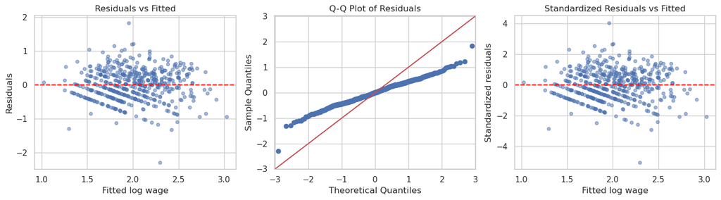

```
Breusch-Pagan heteroscedasticity test: p = 0.0756

Observations with |standardized residual| > 3: 2
```

<style scoped> .dataframe tbody tr th:only-of-type { vertical-align: middle; } .dataframe tbody tr th { vertical-align: top; } .dataframe thead th { text-align: right; } </style> <thead> <th></th> <th>WAGE</th> <th>EDUCATION</th> <th>EXPERIENCE</th> <th>SEX</th> <th>OCCUPATION</th> <th>std_resid</th> </thead> <tbody> <th>170</th> <th>199</th> </tbody>

| 44 | 14 | 1 | 1 | 1 | 4.033244 |
| --- | --- | --- | --- | --- | --- |
| 1 | 12 | 24 | 0 | 1 | -5.061136 |

```python
wage_fitted = wage_model.fittedvalues
wage_resid = wage_model.resid
std_resid = wage_resid / wage_resid.std()

fig, axes = plt.subplots(1, 3, figsize=(14, 4))

axes[0].scatter(wage_fitted, wage_resid, alpha=0.5, s=20)
axes[0].axhline(0, color="red", linestyle="--")
axes[0].set_xlabel("Fitted log wage")
axes[0].set_ylabel("Residuals")
axes[0].set_title("Residuals vs Fitted")

sm.qqplot(wage_resid, line="45", ax=axes[1])
axes[1].set_title("Q-Q Plot of Residuals")

axes[2].scatter(wage_fitted, std_resid, alpha=0.5, s=20)
axes[2].axhline(0, color="red", linestyle="--")
axes[2].set_xlabel("Fitted log wage")
axes[2].set_ylabel("Standardized residuals")
axes[2].set_title("Standardized Residuals vs Fitted")

plt.tight_layout()
plt.show()

bp_stat, bp_p, _, _ = het_breuschpagan(wage_resid, wage_model.model.exog)
print(f"Breusch-Pagan heteroscedasticity test: p = {bp_p:.4f}")

# Flag large standardized residuals (potential outliers)
outlier_cutoff = 3
outliers = cps.loc[np.abs(std_resid) > outlier_cutoff].copy()
outliers["std_resid"] = std_resid[np.abs(std_resid) > outlier_cutoff]
print(f"\nObservations with |standardized residual| > {outlier_cutoff}: {len(outliers)}")
if len(outliers) > 0:
    display(outliers[["WAGE", "EDUCATION", "EXPERIENCE", "SEX", "OCCUPATION", "std_resid"]].head())
```

<p>**Part 2 takeaway:** Wages are right-skewed, so log transformation supports regression. Welch tests highlight raw wage gaps by sex, union status, and region; ANOVA/Kruskal–Wallis compare occupations. The multivariable log-wage model reports adjusted associations (including an estimated gender gap) with confidence intervals, p-values, and R²; diagnostic plots assess model adequacy.</p>

<hr /> <h2 id="Part-3:-Iris-Flower-Measurements-(iris.csv)">Part 3: Iris Flower Measurements (`iris.csv`)</h2><p>**Research questions**</p>

- How do sepal and petal measurements differ across species?
- Are observed differences statistically significant after accounting for multiple species?

<p>**Selected tests and rationale**</p> <thead> <th>Analysis</th> <th>Test</th> <th>Why</th> </thead> <tbody> </tbody>

| Species differences (each measurement) | One-way ANOVA | Standard test for equality of means across 3 groups with balanced *n* |
| --- | --- | --- |
| Non-parametric backup | Kruskal–Wallis | Distribution-free alternative |
| Pairwise follow-up | Tukey HSD | Controls family-wise error rate when ANOVA is significant |

<h3 id="3.1-Load-and-Summarize-Variables">3.1 Load and Summarize Variables</h3>

```python
iris = pd.read_csv(
    DATA_DIR / "iris.csv",
    header=None,
    names=["sepal_length", "sepal_width", "petal_length", "petal_width", "species"],
)

# Standardize species names for readability
iris["species"] = iris["species"].str.replace("Iris-", "", regex=False)

print("First rows:")
display(iris.head())

print("\nCounts by species:")
print(iris["species"].value_counts())

measurement_cols = ["sepal_length", "sepal_width", "petal_length", "petal_width"]
print("\nOverall descriptive statistics:")
display(iris[measurement_cols].describe().T.round(3))

print("\nMeans by species:")
display(iris.groupby("species")[measurement_cols].mean().round(3))
```

```
First rows:
```

<style scoped> .dataframe tbody tr th:only-of-type { vertical-align: middle; } .dataframe tbody tr th { vertical-align: top; } .dataframe thead th { text-align: right; } </style> <thead> <th></th> <th>sepal_length</th> <th>sepal_width</th> <th>petal_length</th> <th>petal_width</th> <th>species</th> </thead> <tbody> <th>0</th> <th>1</th> <th>2</th> <th>3</th> <th>4</th> </tbody>

| 5.1 | 3.5 | 1.4 | 0.2 | setosa |
| --- | --- | --- | --- | --- |
| 4.9 | 3.0 | 1.4 | 0.2 | setosa |
| 4.7 | 3.2 | 1.3 | 0.2 | setosa |
| 4.6 | 3.1 | 1.5 | 0.2 | setosa |
| 5.0 | 3.6 | 1.4 | 0.2 | setosa |

```
Counts by species:
species
setosa        50
versicolor    50
virginica     50
Name: count, dtype: int64

Overall descriptive statistics:
```

<style scoped> .dataframe tbody tr th:only-of-type { vertical-align: middle; } .dataframe tbody tr th { vertical-align: top; } .dataframe thead th { text-align: right; } </style> <thead> <th></th> <th>count</th> <th>mean</th> <th>std</th> <th>min</th> <th>25%</th> <th>50%</th> <th>75%</th> <th>max</th> </thead> <tbody> <th>sepal_length</th> <th>sepal_width</th> <th>petal_length</th> <th>petal_width</th> </tbody>

| 150.0 | 5.843 | 0.828 | 4.3 | 5.1 | 5.80 | 6.4 | 7.9 |
| --- | --- | --- | --- | --- | --- | --- | --- |
| 150.0 | 3.054 | 0.434 | 2.0 | 2.8 | 3.00 | 3.3 | 4.4 |
| 150.0 | 3.759 | 1.764 | 1.0 | 1.6 | 4.35 | 5.1 | 6.9 |
| 150.0 | 1.199 | 0.763 | 0.1 | 0.3 | 1.30 | 1.8 | 2.5 |

```
Means by species:
```

<style scoped> .dataframe tbody tr th:only-of-type { vertical-align: middle; } .dataframe tbody tr th { vertical-align: top; } .dataframe thead th { text-align: right; } </style> <thead> <th></th> <th>sepal_length</th> <th>sepal_width</th> <th>petal_length</th> <th>petal_width</th> <th>species</th> <th></th> <th></th> <th></th> <th></th> </thead> <tbody> <th>setosa</th> <th>versicolor</th> <th>virginica</th> </tbody>

| 5.006 | 3.418 | 1.464 | 0.244 |
| --- | --- | --- | --- |
| 5.936 | 2.770 | 4.260 | 1.326 |
| 6.588 | 2.974 | 5.552 | 2.026 |

<h3 id="3.2-Multi-Group-Comparisons-Across-Species">3.2 Multi-Group Comparisons Across Species</h3>

```python
anova_rows = []
for col in measurement_cols:
    groups = [iris.loc[iris["species"] == sp, col].values for sp in iris["species"].unique()]
    f_stat, f_p = stats.f_oneway(*groups)
    h_stat, h_p = stats.kruskal(*groups)
    anova_rows.append({
        "measurement": col,
        "anova_F_p": f_p,
        "kruskal_p": h_p,
    })

anova_results = pd.DataFrame(anova_rows)
print("One-way ANOVA and Kruskal-Wallis tests (H0: equal distributions/means across species):")
display(anova_results.round(6))

print(
    "\nVery small p-values indicate strong evidence that at least one species differs "
    "from the others for that measurement."
)
```

```
One-way ANOVA and Kruskal-Wallis tests (H0: equal distributions/means across species):
```

<style scoped> .dataframe tbody tr th:only-of-type { vertical-align: middle; } .dataframe tbody tr th { vertical-align: top; } .dataframe thead th { text-align: right; } </style> <thead> <th></th> <th>measurement</th> <th>anova_F_p</th> <th>kruskal_p</th> </thead> <tbody> <th>0</th> <th>1</th> <th>2</th> <th>3</th> </tbody>

| sepal_length | 0.0 | 0.0 |
| --- | --- | --- |
| sepal_width | 0.0 | 0.0 |
| petal_length | 0.0 | 0.0 |
| petal_width | 0.0 | 0.0 |

```
Very small p-values indicate strong evidence that at least one species differs from the others for that measurement.
```

```python
# Tukey HSD post-hoc tests for measurements with significant ANOVA (here: all four)
for col in measurement_cols:
    print(f"\nTukey HSD pairwise comparisons — {col}")
    tukey = pairwise_tukeyhsd(endog=iris[col], groups=iris["species"], alpha=0.05)
    print(tukey.summary())
```

```
Tukey HSD pairwise comparisons — sepal_length
   Multiple Comparison of Means - Tukey HSD, FWER=0.05
=========================================================
  group1     group2   meandiff p-adj lower  upper  reject
---------------------------------------------------------
    setosa versicolor     0.93   0.0 0.6862 1.1738   True
    setosa  virginica    1.582   0.0 1.3382 1.8258   True
versicolor  virginica    0.652   0.0 0.4082 0.8958   True
---------------------------------------------------------

Tukey HSD pairwise comparisons — sepal_width
    Multiple Comparison of Means - Tukey HSD, FWER=0.05
===========================================================
  group1     group2   meandiff p-adj  lower   upper  reject
-----------------------------------------------------------
    setosa versicolor   -0.648   0.0 -0.8092 -0.4868   True
    setosa  virginica   -0.444   0.0 -0.6052 -0.2828   True
versicolor  virginica    0.204 0.009  0.0428  0.3652   True
-----------------------------------------------------------

Tukey HSD pairwise comparisons — petal_length
   Multiple Comparison of Means - Tukey HSD, FWER=0.05
=========================================================
  group1     group2   meandiff p-adj lower  upper  reject
---------------------------------------------------------
    setosa versicolor    2.796   0.0 2.5922 2.9998   True
    setosa  virginica    4.088   0.0 3.8842 4.2918   True
versicolor  virginica    1.292   0.0 1.0882 1.4958   True
---------------------------------------------------------

Tukey HSD pairwise comparisons — petal_width
   Multiple Comparison of Means - Tukey HSD, FWER=0.05
=========================================================
  group1     group2   meandiff p-adj lower  upper  reject
---------------------------------------------------------
    setosa versicolor    1.082   0.0 0.9849 1.1791   True
    setosa  virginica    1.782   0.0 1.6849 1.8791   True
versicolor  virginica      0.7   0.0 0.6029 0.7971   True
---------------------------------------------------------
```

<h3 id="3.3-Visualizations">3.3 Visualizations</h3>

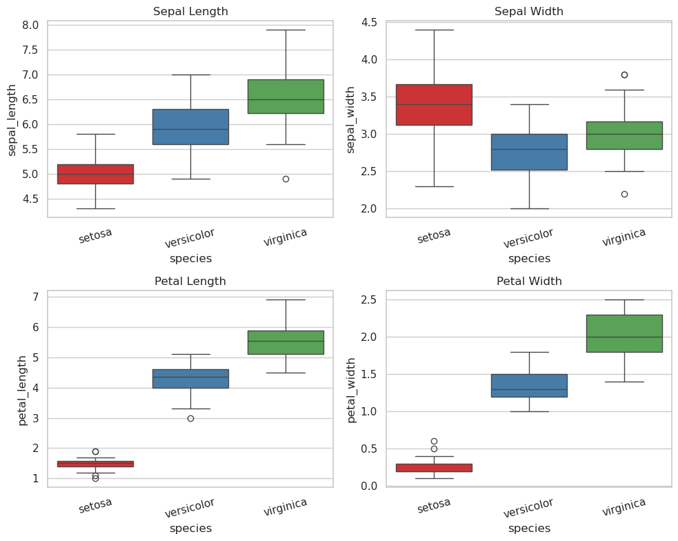

```python
# Boxplots show median and spread for each measurement by species
fig, axes = plt.subplots(2, 2, figsize=(10, 8))
for ax, col in zip(axes.ravel(), measurement_cols):
    sns.boxplot(data=iris, x="species", y=col, ax=ax, palette="Set1")
    ax.set_title(col.replace("_", " ").title())
    ax.tick_params(axis="x", rotation=15)
plt.tight_layout()
plt.show()
```

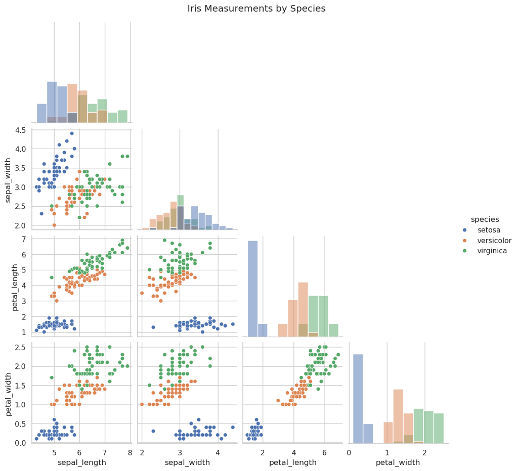

```python
# Pairplot reveals linear separability — petal measurements cluster strongly by species
sns.pairplot(iris, vars=measurement_cols, hue="species", corner=True, diag_kind="hist")
plt.suptitle("Iris Measurements by Species", y=1.02)
plt.show()
```

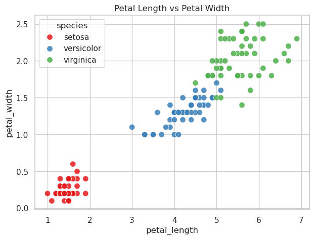

```python
# Petal length vs width colored by species — classic separation pattern
plt.figure(figsize=(7, 5))
sns.scatterplot(
    data=iris, x="petal_length", y="petal_width", hue="species",
    s=70, alpha=0.85, palette="Set1",
)
plt.title("Petal Length vs Petal Width")
plt.show()
```

<h3 id="3.4-Plain-Language-Summary">3.4 Plain-Language Summary</h3><p>The iris dataset contains four flower measurements for three species (*setosa*, *versicolor*, *virginica*), with 50 flowers per species.</p>

- **Sepal variables** differ across species, but distributions overlap more than petal variables do.
- **Petal length and petal width** show the clearest separation: *setosa* has small petals, while *versicolor* and *virginica* have larger petals, with *virginica* tending to be largest.
- One-way ANOVA confirms that mean measurements are not equal across species (very small p-values for all four variables). Tukey follow-up tests identify which species pairs differ.
- In practice, petal measurements alone could often distinguish species, which is why the iris data are commonly used to teach classification — but here we focus on classical group comparisons and visualization.

<hr /> <h2 id="Conclusion">Conclusion</h2><p>This notebook walked through three complementary workflows:</p>

1. **Brain size:** descriptive exploration, gender comparisons with Welch/Mann–Whitney tests, and an adjusted linear model relating FSIQ to MRI_Count with assumption diagnostics.
2. **CPS wages:** data cleaning, skewed wage distributions, group comparisons, and a log-wage regression interpreting coefficients as approximate percentage effects.
3. **Iris:** multi-group ANOVA/Kruskal–Wallis testing and visual evidence of species separation.

<p>Together, these analyses illustrate how to choose tests based on the number of groups, distribution shape, and modeling goals — and how to validate regression assumptions before drawing conclusions.</p>